# presentation-live

## Mají tučňáci s delší ploutví také vyšší tělesnou hmotnost?

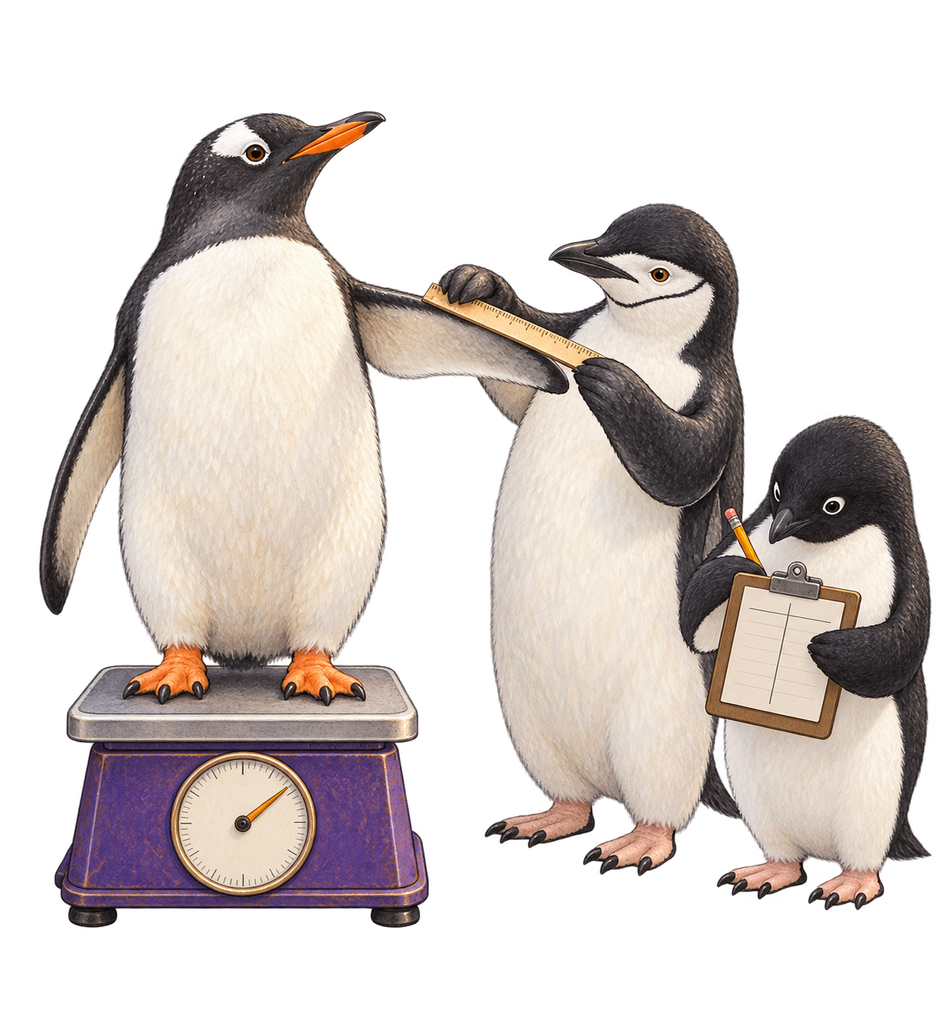

BIOSTATISTIKA

L02

Vztahy dvou proměnných a vizualizace

cuni-natur-biostatistics.github.io/materialy.html

Ilustrace vytvořená pomocí AI.

## Pomůže nám druhá proměnná?

Naše biologická otázka Mají tučňáci s delší ploutví také vyšší tělesnou hmotnost?

Ilustrace: [Allison Horst](https://allisonhorst.com/)

## Co si pamatujete z minulé lekce?

Odpovězte samostatně na tři krátké otázky. Na telefonu neuvidíte odpovědi ostatních; společné výsledky otevřeme až po hlasování.

[figure not shown]

[Otevřít dotazník v novém okně](https://pollslive.com/p/l02-opakov-n-p-edchoz-lekce-2026-27-utpy9nkm)

## Jak odpovídala skupina?

[interactive chart not shown]

[Otevřít výsledky mimo prezentaci](https://pollslive.com/p/l02-opakov-n-p-edchoz-lekce-2026-27-utpy9nkm?view=results)

## Který z uvedených druhů spí podle tabulky nejdéle?

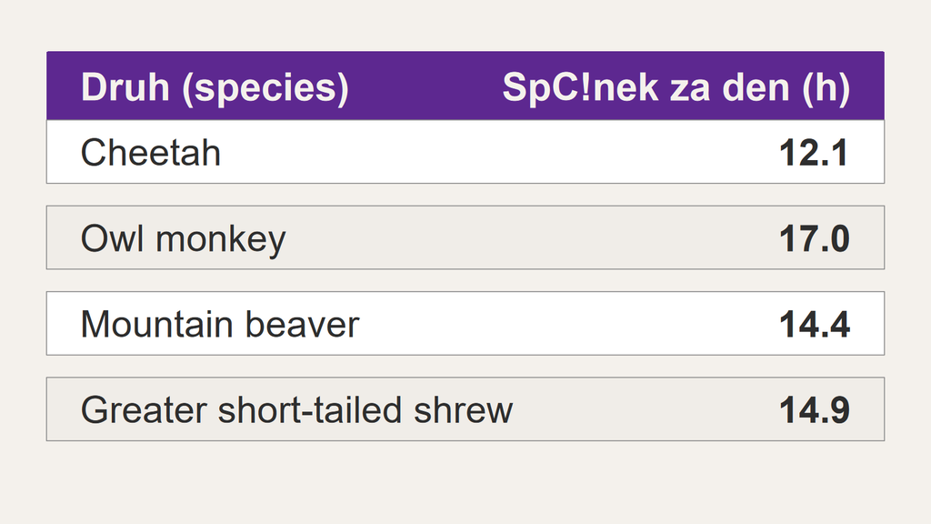

- Cheetah
- Owl monkey
- Mountain beaver
- Greater short-tailed shrew

Správná odpověď: Owl monkey

Porovnáme hodnoty ve sloupci Spánek za den (h). Nejvyšší hodnota je 17.0 h v řádku Owl monkey.

## Ve kterém intervalu délky spánku je podle histogramu nejvíce zastoupených druhů?

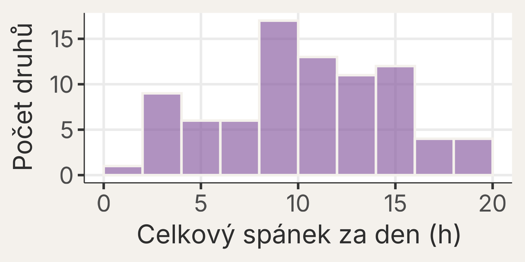

- 10–12 h
- 12–14 h
- 8–10 h
- 16–18 h

Správná odpověď: 8–10 h

Nejvyšší sloupec stojí nad intervalem 8–10 h. Poloha sloupce na vodorovné ose určuje interval spánku; jeho výška vyjadřuje počet druhů v tomto intervalu.

## Jaká je podle výstupu průměrná délka spánku devíti druhů?

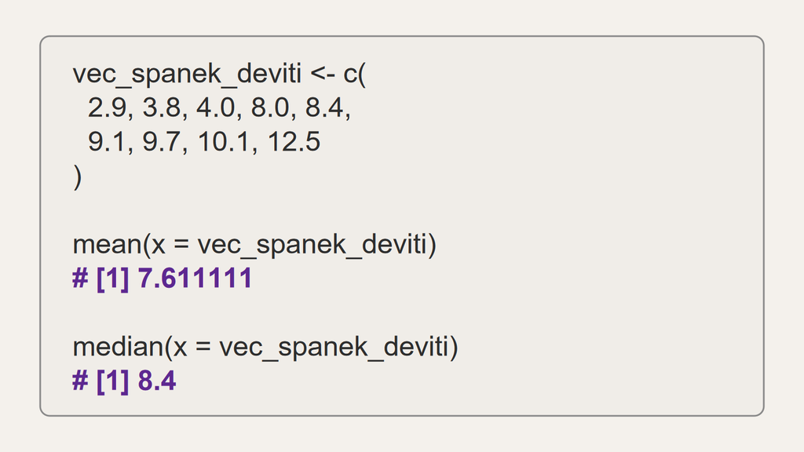

- 7.611111 h
- 8.4 h
- 4.0 h
- 9.1 h

Správná odpověď: 7.611111 h

Průměr vypočítává funkce mean(), která vrací 7.611111 h. Funkce median() vrací 8.4 h; hodnoty 4.0 h a 9.1 h jsou jednotlivá pozorování ve vektoru.

## Výsledky učení

Po absolvování této přednášky budete schopni:

- přečíst bodový graf dvou numerických proměnných: směr, tvar a rozptýlení bodů
- vysvětlit, proč jsou biologická data rozptýlená i při zřetelném vztahu a co k popisu přidá korelace
- zvolit vhodný první graf podle typu dvojice proměnných
- rozlišit popis asociace od tvrzení o její příčině

# Dvě měření, jeden bod

## Od jedné proměnné ke dvěma

V minulé lekci jsme četli jednu proměnnou

Z tabulky, histogramu nebo číselného souhrnu jsme zjišťovali, jak vypadají hodnoty jedné proměnné.

Dvojice musí zůstat spolu

Dva oddělené histogramy neukážou, které dvě hodnoty patří stejnému tučňákovi.

## Dvě hodnoty patří jednomu tučňákovi

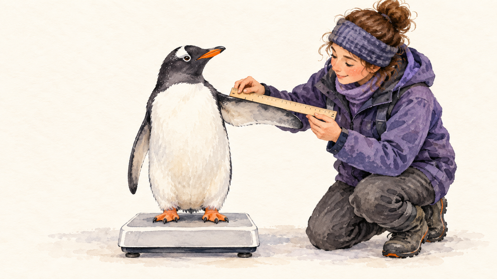

Ilustrační obraz vytvořen AI.

Dvojice měření musí zůstat spojena se stejným pozorováním.

## Diskuze se sousedem

Naše biologická otázka Mají tučňáci s delší ploutví také vyšší tělesnou hmotnost?

Jak by podle vás mohl vypadat graf pro zodpovězení této otázky?

*30 s přemýšlení — pak sdílejte svůj odhad se sousedem.*

## Tabulka tučňáků

| Druh | Délka ploutve (mm) | Hmotnost (g) |
| --- | --- | --- |
| Adelie | 181 | 3750 |
| Adelie | 186 | 3800 |
| Adelie | 195 | 3250 |

Jeden řádek = jeden tučňák

Které dvě hodnoty z jednoho řádku vytvoří jeden bod grafu?

Data: palmerpenguins 0.1.1, CC0. Celkem 344 řádků.

## Úplné dvojice v R

```r
data_puvodni <-
  read.csv(
    file = "data/palmer_penguins.csv",
    na.strings = ""
  )
vec_uplne <-
  complete.cases(
    data_puvodni$flipper_length_mm,
    data_puvodni$body_mass_g
  )
data_pary <- data_puvodni[vec_uplne, ]
data_tucnaci <-
  data.frame(
    druh_tucnaka = data_pary$species,
    ostrov = data_pary$island,
    delka_ploutve_mm = data_pary$flipper_length_mm,
    hmotnost_g = data_pary$body_mass_g
  )
```

344 řádků

2 řádky bez obou měření

**342 úplných dvojic**

Neúplný řádek vynecháme celý, aby se dvojice měření nerozpojila.

CSV Palmer Penguins: uložte do složky `data` ve svém projektu v R.

## Dva tučňáci

```r
vec_delka_ploutve_mm <-
  c(181, 186)

vec_hmotnost_g <-
  c(3750, 3800)

plot(
  x = vec_delka_ploutve_mm,
  y = vec_hmotnost_g,
  xlab = "Délka ploutve (mm)",
  ylab = "Tělesná hmotnost (g)",
  pch = 16
)
```

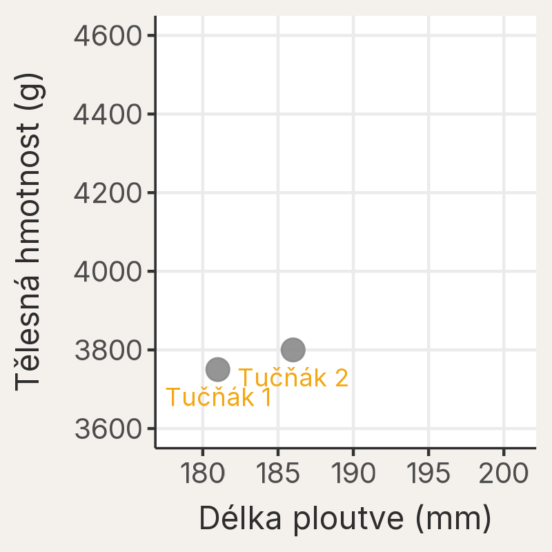

## Čtyři tučňáci

```r
vec_delka_ploutve_mm <-
  c(181, 186, 190, 198)

vec_hmotnost_g <-
  c(3750, 3800, 4250, 4400)

plot(
  x = vec_delka_ploutve_mm,
  y = vec_hmotnost_g,
  xlab = "Délka ploutve (mm)",
  ylab = "Tělesná hmotnost (g)",
  pch = 16
)
```

[output not shown]

## Všichni tučňáci

```r
plot(
  x = data_tucnaci$delka_ploutve_mm,
  y = data_tucnaci$hmotnost_g,
  xlab = "Délka ploutve (mm)",
  ylab = "Tělesná hmotnost (g)",
  pch = 16
)
```

[output not shown]

## Co v tomto grafu vidíte?

- Směr: rostoucí
- Rozptýlení: oblak zůstává široký
- Závěr: vzor vidíme, příčinu z grafu neurčíme

## Stejná data, jiné osy

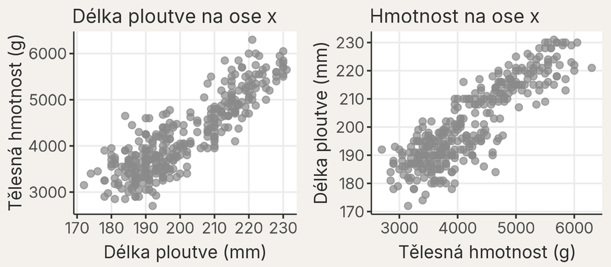

Změnil se vztah mezi délkou ploutve a hmotností, když jsme osy prohodili?

Oblak se jen zrcadlově převrátí podle úhlopříčky. Směr ani těsnost vztahu se nezmění; tytéž dvojice měření zůstávají spojené.

## Rozptýlení čteme ve dvou směrech

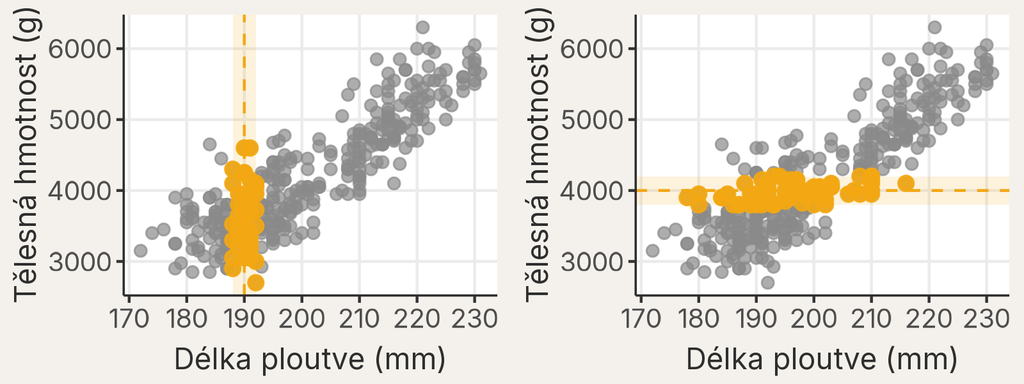

Podobná délka ploutve, různá hmotnost

Podobná hmotnost, různá délka ploutve

Když čteme bodový graf, díváme se současně na směr vztahu i na to, jak široký oblak zůstává v obou směrech.

Co už můžeme tvrdit? Která formulace je v této chvíli nejlepší?

A

V grafu je vidět vztah, takže jsme prokázali příčinu.

B

V datech je vidět biologicky smysluplný vzor, který chceme popsat přesněji.

C

Protože body neleží na jedné přímce, mezi proměnnými žádný vztah není.

Než hlasujeme: přesvědčte souseda, proč jste vybrali svoji možnost.

## Mají tučňáci s delší ploutví také vyšší tělesnou hmotnost?

*Mají tučňáci s delší ploutví také vyšší tělesnou hmotnost?*

Signál

Delší ploutve **bývají spojeny** s vyšší hmotností.

Rozptýlení

Vztah **není** dokonale těsný.

POZOR Graf popisuje asociaci; její příčinu ani nejistotu z tohoto obrázku neurčíme.

## Stejná data, ale s druhem

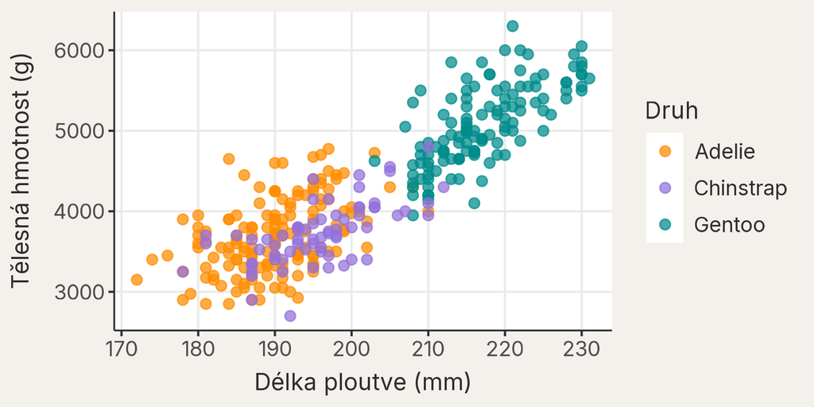

## Co se po obarvení změnilo?

Biologická logika platí i po obarvení podle druhu

- Směr oblaku zůstává kladný
  - *tučňáci s delší ploutví bývají těžší*
- Rozptýlení má biologickou strukturu
  - část variability pochází z míchání více druhů

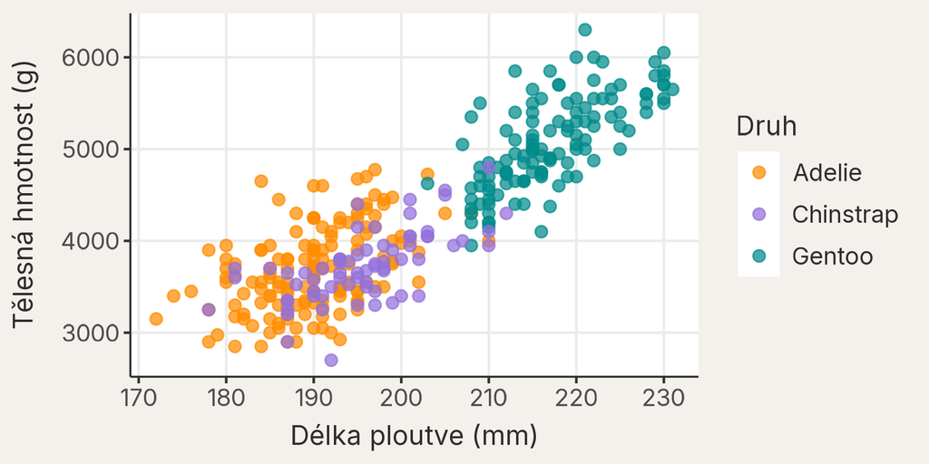

## Jedno číslo pro společný pohyb

Co by takové číslo muselo umět?

Řekněte sousedovi aspoň jednu vlastnost

30 s každý — pak porovnejte, co jste vymysleli.

Zachytit směr a těsnost vztahu a nezáviset na tom, v jakých jednotkách měříme.

# Jak spočítat společný pohyb?

## Průměry v grafu

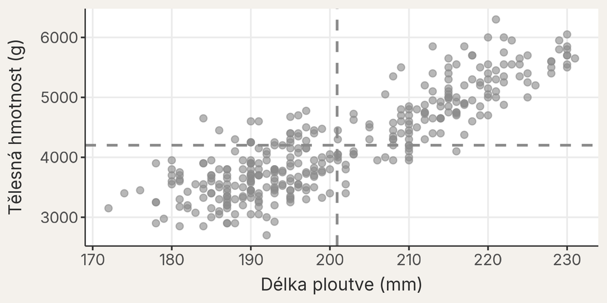

Střed grafu určíme dvěma průměry: délka 200.9 mm, hmotnost 4202 g.

## Jeden bod pod lupou

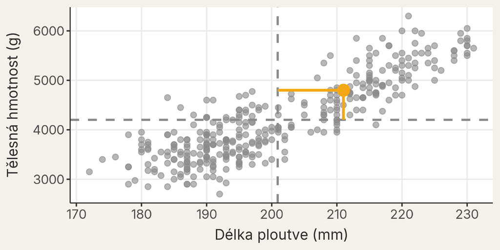

Bod nad průměrem v obou proměnných

Obě odchylky jsou kladné → jejich **součin** je také **kladný**.

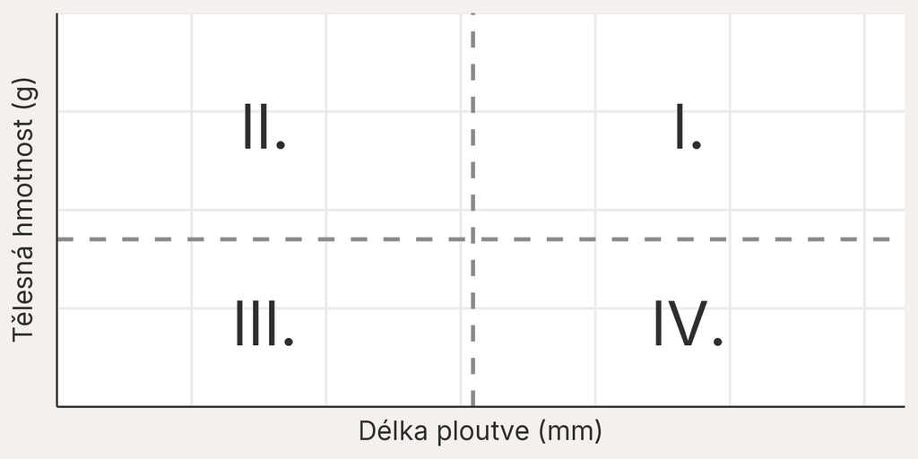

## Ve které další části grafu budou součiny také kladné?

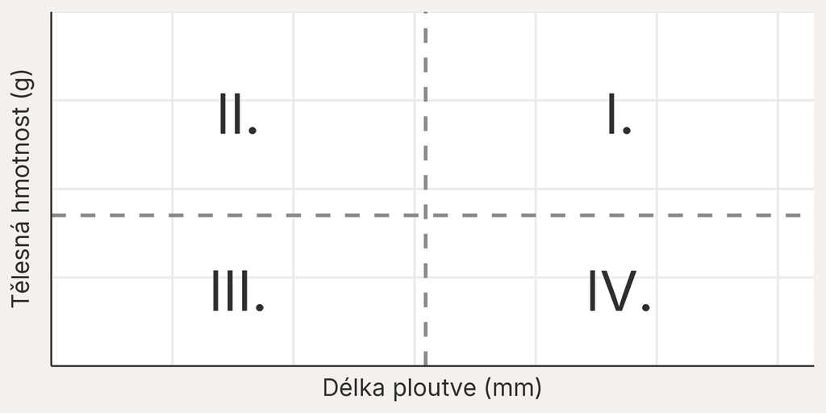

I. a III. kvadrant

Vpravo nahoře a vlevo dole.

II. a IV. kvadrant

Vlevo nahoře a vpravo dole.

Všechny čtyři stejně

Na poloze vůči středu nezáleží.

Než hlasujeme: vysvětlete sousedovi znaménka obou odchylek v jedné možnosti.

## Čtyři tučňáci ručně

Průměry:

Délka ploutve: **188,75** mm

Hmotnost: **4050** g

| Délka | Hmotnost | Délka odch. | Hmotnost odch. |
| --- | --- | --- | --- |
| 181 | 3750 | -7,75 | -300 |
| 186 | 3800 | -2,75 | -250 |
| 190 | 4250 | 1,25 | 200 |
| 198 | 4400 | 9,25 | 350 |

## Kovariance je „průměr součinů odchylek“

kovariance = **součet součinů odchylek** / (**počet pozorování** − 1)

Kovariance sčítá součiny odchylek. Rozhoduje znaménko i velikost každého součinu, nikoli samotný počet bodů v kvadrantech.

| Délka odch. | Hmotnost odch. | Součin |
| --- | --- | --- |
| -7,75 | -300 | 2325 |
| -2,75 | -250 | 687,5 |
| 1,25 | 200 | 250 |
| 9,25 | 350 | 3237,5 |

součet součinů odchylek = 6500

počet pozorování − 1 = 3

kovariance = 6500 / 3 ≈ **2166,67 mm·g**

## Odchylky a jejich součiny v R

```r
vec_prumer_delky <-
  mean(x = vec_delka_ploutve_mm)
vec_prumer_hmotnosti <-
  mean(x = vec_hmotnost_g)
vec_odchylka_delky <-
  vec_delka_ploutve_mm - vec_prumer_delky
vec_odchylka_hmotnosti <-
  vec_hmotnost_g - vec_prumer_hmotnosti
vec_souciny <-
  vec_odchylka_delky * vec_odchylka_hmotnosti
```

Každý součin patří jednomu ze stejných čtyř pozorovaných tučňáků.

## Stejný výpočet pomocí `cov()`

```r
vec_soucin <-
  sum(vec_souciny)
vec_pocet_minus_jedna <-
  length(x = vec_souciny) - 1
vec_kovariance <-
  vec_soucin / vec_pocet_minus_jedna
vec_kovariance
```

```
[1] 2166.667
```

```r
vec_kovariance <-
  cov(
    x = vec_delka_ploutve_mm,
    y = vec_hmotnost_g
  )
vec_kovariance
```

```
[1] 2166.667
```

## Záleží na jednotkách?

Co se stane s kovariancí, když délku ploutve přepočteme na centimetry a hmotnost na kilogramy?

Stejní tučňáci: všech 342 úplných dvojic.

V milimetrech a gramech

Kovariance: 9 824 (mm·g)

V centimetrech a kilogramech

Kovariance: 0,982 (cm·kg)

Směr vztahu se nezměnil, ale číslo ano. Proto chceme bezrozměrný souhrn: korelaci.

# Číslo nezávislé na jednotkách

## Kovariance bez jednotek: Pearsonovo *r*

Pearsonova korelace

*r* = kovariance / (SD délky ploutve × SD hmotnosti)

Jednotky v čitateli i jmenovateli se vykrátí.

- *r* leží vždy mezi −1 a 1
- znaménko ukazuje směr vztahu
- čím blíž ±1, tím těsněji leží body u přímky
- v R: `cor()`

*r* je doplněk ke grafu, ne jeho náhrada.

## Odhadněte korelaci

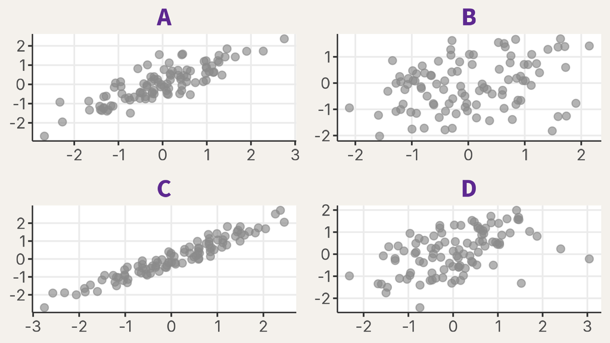

Seřaďte grafy A–D od nejslabšího po nejtěsnější vztah. Jaké *r* odhadujete pro nejtěsnější z nich?

## Stejná data, ale s hodnotou *r*

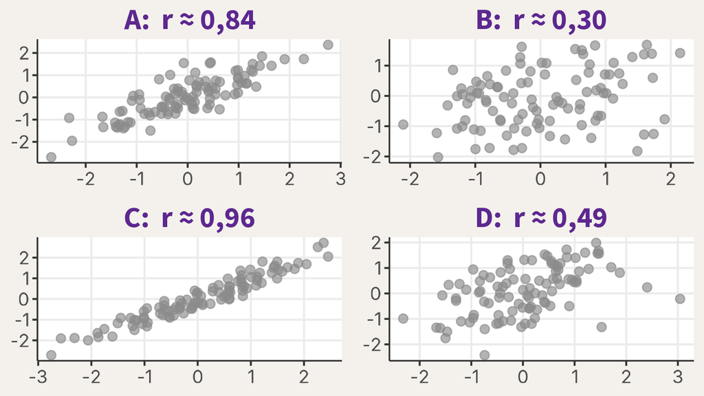

Čím těsněji body leží podél přímky, tím blíž je *r* k 1.

Zkonstruované výukové příklady; popisky uvádějí korelaci spočtenou ze zobrazených bodů.

## Výš v horách, chladněji?

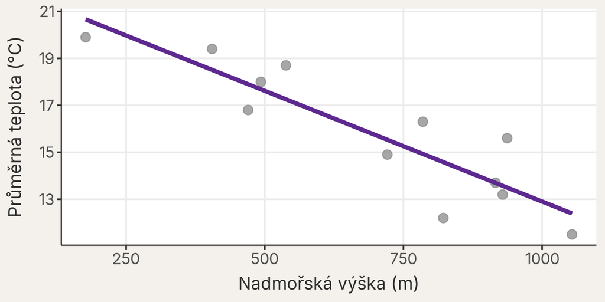

Záporné *r* = -0,89: s vyšší nadmořskou výškou průměrná teplota klesá.

Zkonstruovaný výukový příklad nadmořské výšky a teploty; nejde o terénní měření.

## Čtyři tučňáci v kódu

```r
vec_delka_ploutve_mm <-
  c(181, 186, 190, 198)

vec_hmotnost_g <-
  c(3750, 3800, 4250, 4400)

cor(
  x = vec_delka_ploutve_mm,
  y = vec_hmotnost_g,
  method = "pearson"
)
```

```
[1] 0.9309851
```

## Všichni tučňáci v kódu

```r
cor(
  x = data_tucnaci$delka_ploutve_mm,
  y = data_tucnaci$hmotnost_g,
  method = "pearson"
)
```

```
[1] 0.8712018
```

*r* ≈ 0,87: silný rostoucí vztah — a přesto při stejné délce ploutve zůstává rozptýlení hmotnosti.

## Pořadí místo hodnot: Spearmanova korelace

Spearmanova korelace

Hodnoty nahradí jejich **pořadím** (nejkratší ploutev = 1, druhá nejkratší = 2, …) a korelaci spočítá z pořadí.

- ptá se, zda vztah **stále roste** (nebo stále klesá), i když není přímkou
- jednotlivá vzdálená pozorování ji ovlivní méně

```r
cor(
  x = data_tucnaci$delka_ploutve_mm,
  y = data_tucnaci$hmotnost_g,
  method = "spearman"
)
```

```
[1] 0.8399741
```

U tučňáků vychází podobně jako Pearson (0,87 a 0,84): oblak roste zhruba po přímce.

## Kde se Pearson a Spearman mohou lišit?

Který z těchto tří grafů podle vás povede k největšímu rozdílu mezi oběma koeficienty?

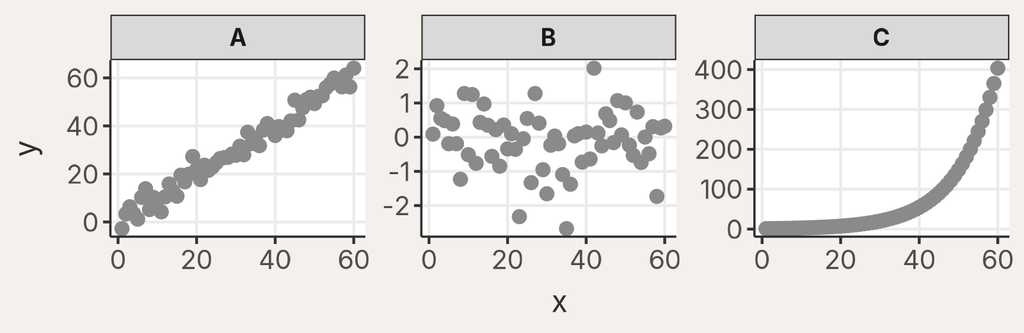

Největší rozdíl: **C**. Pořadí roste, ale vztah není přímka: Pearson **0,82**, Spearman **1,00**.

Zkonstruované výukové příklady; nejde o měření tučňáků.

## Rostoucí vztah nemusí být přímka

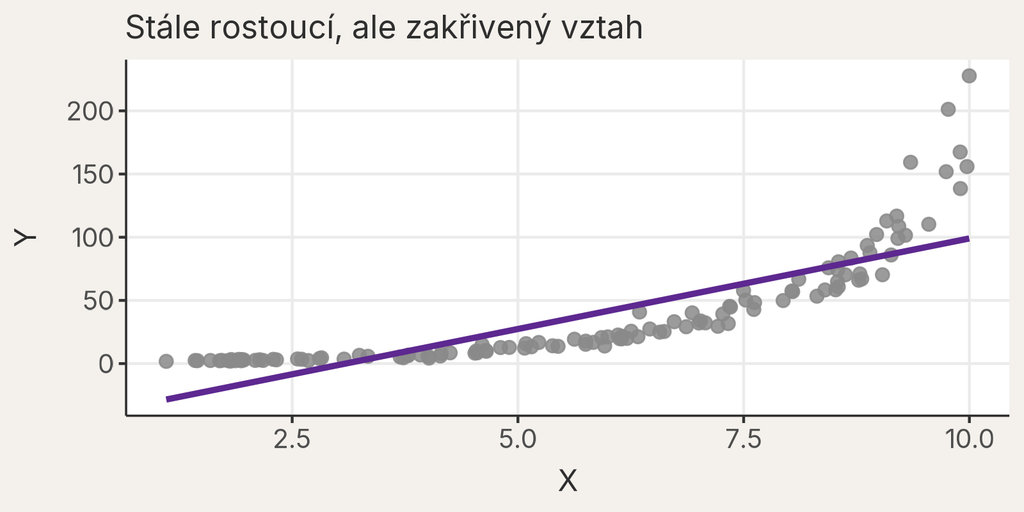

Stejný typ vztahu jako v grafu C, tentokrát s rozptýlenými body. Pearson 0,82, Spearman 0,99: pořadí hodnot roste téměř dokonale, ale body neleží na přímce.

Zkonstruovaný výukový příklad; nejde o měření tučňáků.

## Čtyři situace korelace

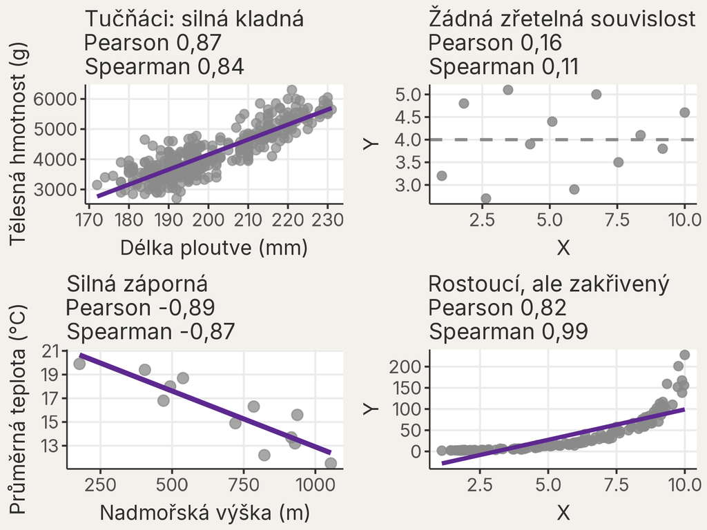

## Čtyři soubory, stejná čísla

| Soubor | Průměr x | Průměr y | Rozptyl x | Rozptyl y | r |
| --- | --- | --- | --- | --- | --- |
| A | 9,00 | 7,50 | 11,00 | 4,13 | 0,82 |
| B | 9,00 | 7,50 | 11,00 | 4,13 | 0,82 |
| C | 9,00 | 7,50 | 11,00 | 4,12 | 0,82 |
| D | 9,00 | 7,50 | 11,00 | 4,12 | 0,82 |

Mají všechny čtyři soubory stejný vztah mezi x a y?

Načrtněte sousedovi, jak by mohl vypadat bodový graf jednoho z nich.

Anscombův kvartet (Anscombe 1973); data `anscombe` jsou součástí R.

## Stejná čísla, jiné grafy

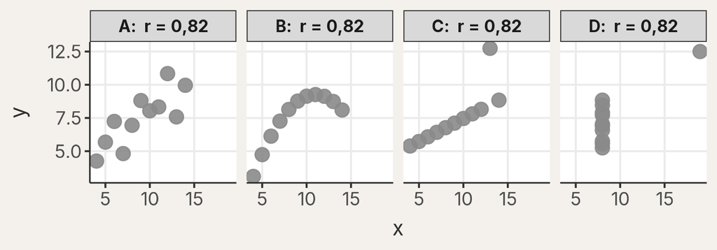

**A** rozptýlená přímka

**B** křivka

**C** přímka a jeden vzdálený bod

**D** jediný bod vytváří „vztah“

Stejné průměry, rozptyly i *r* mohou popisovat úplně jiné vztahy. Proto se nejdřív díváme na graf.

Anscombův kvartet (Anscombe 1973); data `anscombe` jsou součástí R.

## Co nám to říká právě o tučňácích?

*Mají tučňáci s delší ploutví také vyšší tělesnou hmotnost?*

Pearson i Spearman vyšly podobně

Pearson: 0,87, Spearman: 0,84.

Graf ukázal rostoucí oblak. Oba koeficienty shrnují celkovou asociaci; vztahy uvnitř druhů mohou být jiné.

Korelace neřekne, odkud vztah pochází

Část vztahu může souviset s druhem nebo celkovou velikostí těla.

## Korelace ukazuje asociaci, ne příčinu

[figure not shown]

Společná změna dvou proměnných

Korelace popisuje, zda se dvě proměnné mění společně.

Sama neoddělí příčinu

Korelace sama neodliší přímý efekt od sdílené příčiny.

Fotografie: internetový mem, autor neuveden.

# Jak vybrat první graf?

## Tři dvojice, tři různé otázky

Délka ploutve × hmotnost

Druh tučňáka × hmotnost

Druh tučňáka × ostrov

Skupinka 3–4 · 2 min

Ke každé dvojici navrhněte první graf a jednou větou zdůvodněte, co z něj chcete přečíst.

## Ploutev × hmotnost: body, nebo barva?

Numerická × numerická: obě proměnné mají číselnou osu

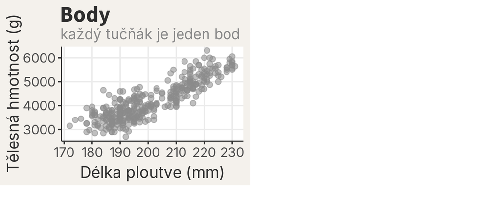

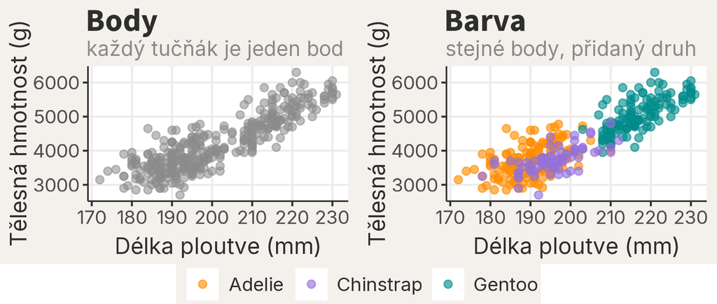

Každý tučňák je jeden bod: první volba pro dvě numerické proměnné.

Barva nepřidá osu, ale novou otázku: je vztah stejný ve všech skupinách?

## Ploutev × hmotnost: kde je bodů nejvíc?

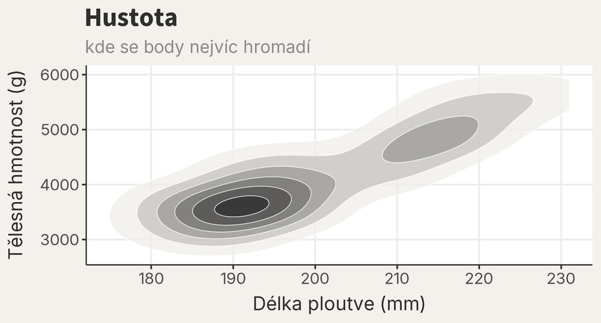

**Hustota** odpovídá na jinou otázku: kde je dat nejvíc? Jednotlivé body ale zmizí.

## Druh × hmotnost: body, nebo krabice?

Kategoriální × numerická: jedna proměnná vytváří skupiny, druhá je číslo

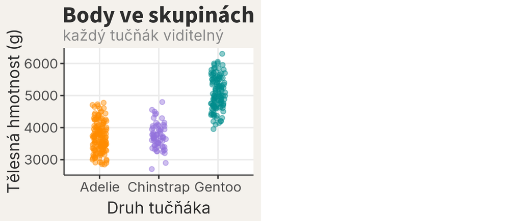

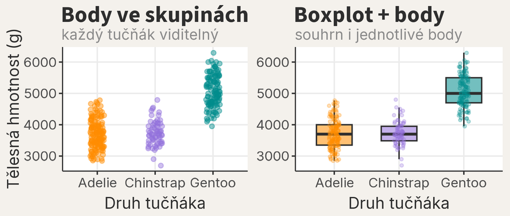

**Body ve skupinách** nic neskrývají: vidíme každého tučňáka.

**Boxplot** dá rychlý souhrn, ale samotná krabice by skryla tvar dat.

## Druh × hmotnost: jaký tvar má rozložení?

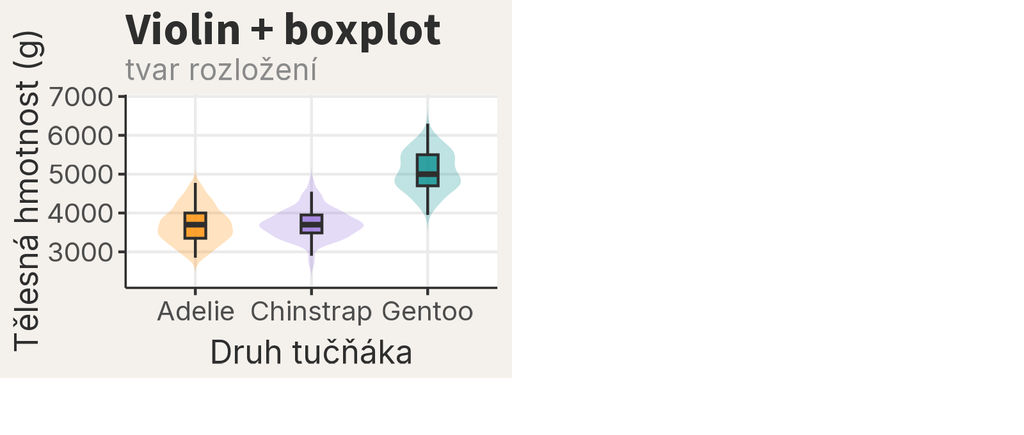

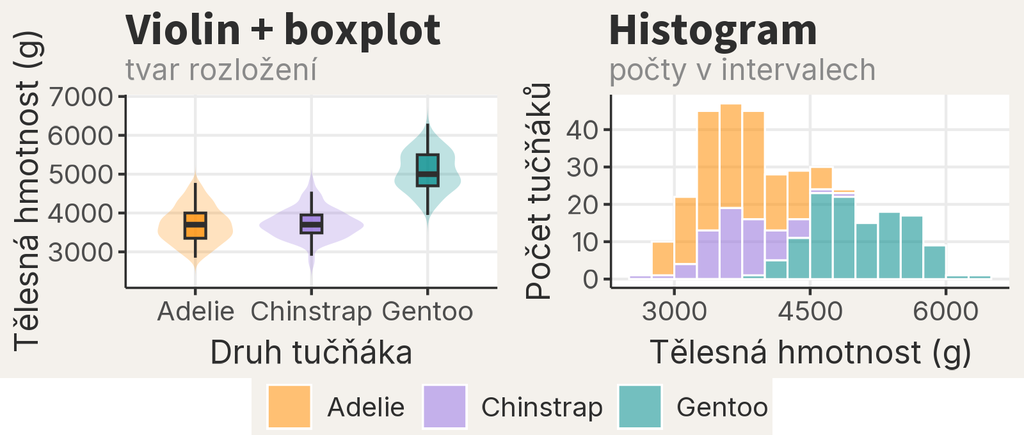

**Violin** ukáže tvar rozložení; krabice uvnitř dá rychlý souhrn.

**Histogram** ukáže skutečné počty tučňáků v intervalech hmotnosti.

## Druh × hmotnost: který druh převažuje?

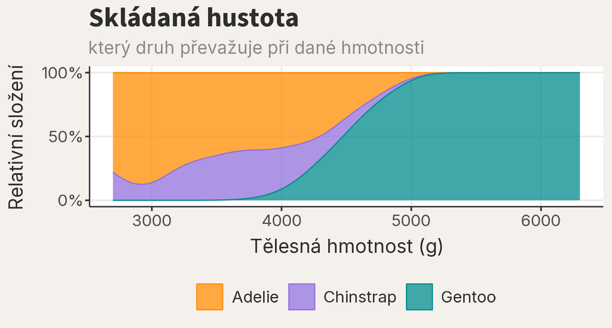

**Skládaná hustota** neukazuje počty. Ukazuje relativní složení druhů podél hmotnosti.

## Který graf byste udělali jako první?

Otázka: liší se tělesná hmotnost mezi druhy a jak moc se druhy překrývají?

Body ve skupinách

Vidíme každého tučňáka.

Boxplot + body

Rychleji čteme typickou hodnotu a rozptýlení.

Violin / histogram

Lépe čteme tvar nebo počty v intervalech.